# Verifica di Ipotesi con $x_{critico}$

Ottavia M. Epifania

19/4/2022

Per rispondere alla sua domanda è meglio ricorrere alle rappresentazioni grafiche.

Prendiamo ad esempio la verifica di ipotesi bidirezionale con $\alpha = .05$, da cui si ricava facilemente $z_{critico} = 1.96$ e le conseguenti aree di rifituo e di accettazione dell’ipotesi nulla. Graficamente:

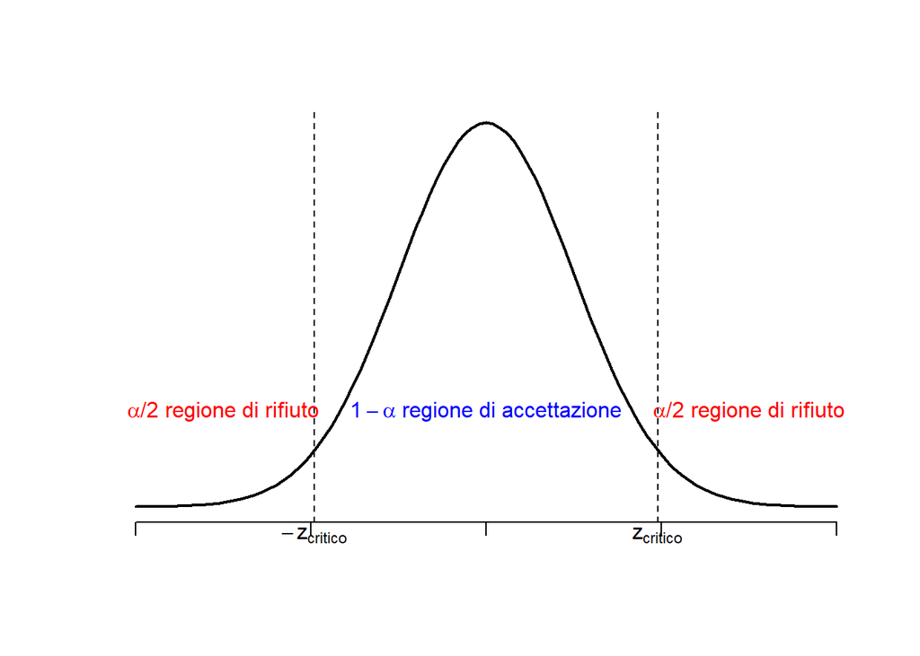

Dato questo grafico, se $z_{campionario} < -z_{critico}$, si rifiuta $H_0$, in quanto $z_{campionario}$ si trova nella regione di rifiuto definita da $\alpha/2$ sulla sinistra della coda della distribuzione. Similmente, se $z_{campionario} > z_{critico}$, si rifiuta $H_0$, in quanto $z_{campionario}$ si trova nella regione di rifiuto definita da $\alpha/2$ sulla destra della coda della distribuzione. Viceversa, se $- z_{critico} < z_{campionario} < z_{critico}$, $H_0$ viene accettata perché $z_{campionario}$ si trova nella regione di accettazione di $H_0$ definita da $1- \alpha$.

Lo stesso identico ragionamento si applica quando $z_{critico}$ viene trasfromato in $x_{critico}$. Graficamente:

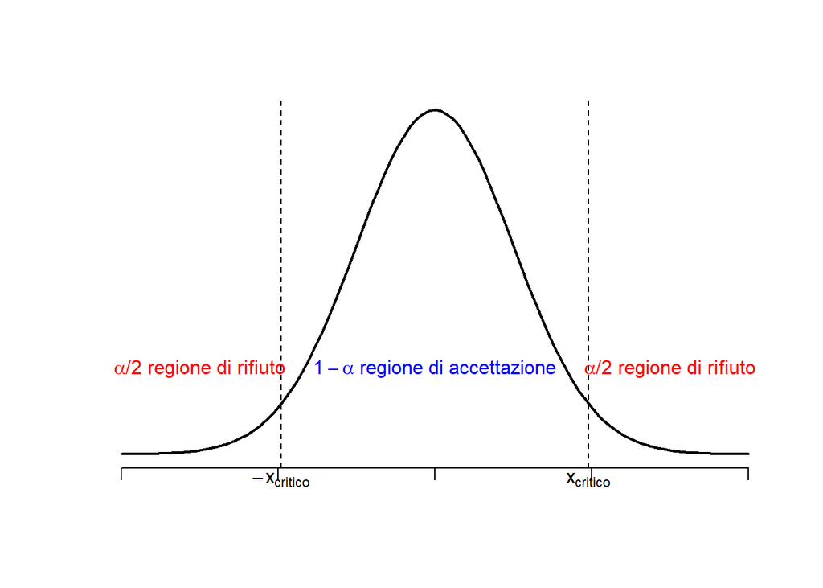

Dato questo grafico, se $\bar{x} < -x_{critico}$, si rifiuta $H_0$, in quanto $\bar{x}$ si trova nella regione di rifiuto definita da $\alpha/2$ sulla sinistra della coda della distribuzione. Similmente, se $\bar{x} > x_{critico}$, si rifiuta $H_0$, in quanto $\bar{x}$ si trova nella regione di rifiuto definita da $\alpha/2$ sulla destra della coda della distribuzione. Viceversa, se $- x_{critico} < \bar{x} < x_{critico}$, $H_0$ viene accettata perché $\bar{x}$ si trova nella regione di accettazione di $H_0$ definita da $1- \alpha$.